# Flux Partitioning

## Background

## Motivation

NEE is net flux of two gross fluxes. IThe third post-processing step is partitioning the net flux (NEE) into its gross components \(GPP\) and \(R_{eco}\).

\[ NEE = R_{eco} - GPP \]

**Nighttime-Partitioning**

estimate \(R_{eco} \sim T\) relationship of nighttime NEE (where \(GPP = 0\))

**Daytime-Partitioning**

fit a model of \(NEE\) to global radiation, VPD and temperature.

## Sort records to Daytime and Nighttime

The partitioning needs to distinguish carefully between night-time and day-time records.

classified as nighttime, if

1. Threshold of \(Rg < 10\, W m^{-2}\)
2. Daytime between compute times of sunrise and sunset

## Nighttime flux partitioning

## Temperature sensitivity: \(E_0\)

Respiration is modelled by eq. of Lloyd & Tayler (1994)

\[ R_{eco}(T; R_{Ref}, E_0) = R_{Ref} \, \text{exp} \left[ E_0 \left( \frac{1}{T_{Ref}-T_{0}} - \frac{1}{T-T_{0}} \right) \right] \] where \(T_0 = -46.02°C\) and Reference temperature \(T_{Ref} = 15°C\).

Temperature sensitivity, \(E_0\), is fitted to successive 15-day periods on trimmed data.

Annually aggregated, \(E_0\) is then the mean across valid estimates where 1) there were at least six records, 2) temperate ranged across at least 5°C, and 3) estimates were inside range of 30 to 450K.

## Respiration at reference temperature: \(R_{Ref}\)

Respiration at reference temperature, \(R_{Ref}\), is re-estimated from nighttime data

- using the annual \(E_0\) temperature sensitivity estimate
- for 7-day windows shifted consecutively for 4 days.

Then its assigned to the central time-point of the 4-day period and linearly interpolated between periods.

Hence, the obtained respiration-temperature relationship varies across time.

## Daytime flux partitioning

## Light response curve (LRC)

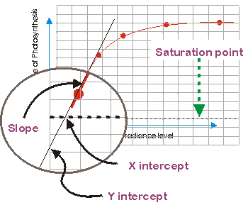

## Fitting the Light responce curve (LRC)

The method of Lasslop (2010) models \(NEE\):

\[ NEE = -GPP(Rg, VPD; \alpha, \beta_0, k) + R_{eco}(T; R_{Ref}, E_0) \] \[ GPP = \frac{\alpha \beta R_g}{ \alpha R_g + \beta} \] \[ \beta = \begin{cases} \beta_0 \, \text{exp} \left[ -k (\operatorname{VPD} - \operatorname{VPD}_0) \right] \text{ if VPD > 10 hPa} \\ \beta_0 \text{ otherwise} \end{cases} \]

\(\alpha\) (\(\mu mol \, CO_2 \, J^{-1}\)) is the canopy light utilization efficiency and represents the initial slope of the light-response curve,

\(\beta\) (\(\mu mol\, CO_2\, m^{-2} s^{-1}\)) is the maximum CO2 uptake rate of the canopy at infinite Rg, which is a decreasing function at higher VPD values.

## Temperature sensitivty

Temperature sensitivity, \(E_0\) is estimated from night-time data and provided to the day-time LRC fit to avoid parameter identifyability problems.

Different from the nigh-time partitioning a smoothed time varying estimate is used instead of the annual aggregate. And during \(E_0\) estimation, reference temperature \(R_{Ref}\) is set to the median temperature of the time window.

## LRC parameters and Reference temperature \(R_{Ref}\)

Are fitted using only daytime data and the previously determined temperature sensitivity (\(E_0\)) for each shifting window across records.

## Gross fluxes: \(R_{eco}\) and \(GPP\)

Are predcted by the LRC and Lloyd & Taylor respiration for each central record of the shifting window.

Results are linearly interpolated by the difference to the window centers.

**Lasslop 2010**

Daytime estimates of reference temperatures are also used for predicting nighttime \(R_{eco}\)

**Keenan 2019**

Nighttime estiamtes of reference temperatures (obtained with the \(E_0\) fits) are used for predicting nighttime \(R_{eco}\)

## Caution Partitioning is not always applicable

Partitioning only works if there is a good \(R_{eco} \sim T\) relationship.

It is not applicable if either there is

- Suppressed respiration at freezing temperatures
- Limited variation of temperature
- Strong controls of other factors such as moisture

## Flux Partitioning in REddyProc

## Preparations

Specify geographical coordinates and time zone.

Fill mssing values in the used meteorological data.

```r
EProc$sSetLocationInfo(LatDeg = 51.0, LongDeg = 13.6, TimeZoneHour = 1)
EProc$sMDSGapFill('Tair', FillAll = FALSE,  minNWarnRunLength = NA)
EProc$sMDSGapFill('VPD', FillAll = FALSE,  minNWarnRunLength = NA)
EProc$sMDSGapFill('Rg', FillAll = FALSE,  minNWarnRunLength = NA)
```

## Nighttime partitioning

Repeated for each of the \(u_*\) threshold scenario (percentiles of \(u_{*Th}\) distribution)

```r
EProc$sMRFluxPartitionUStarScens()
grep("GPP|Reco",names(EProc$sExportResults()), value = TRUE)
```

```
##  [1] "Reco_U05"      "GPP_U05_f"     "GPP_U05_fqc"   "Reco_U50"
##  [5] "GPP_U50_f"     "GPP_U50_fqc"   "Reco_U95"      "GPP_U95_f"
##  [9] "GPP_U95_fqc"   "Reco_uStar"    "GPP_uStar_f"   "GPP_uStar_fqc"
```

It produces output columns `Reco_<uStar>` and `GPP_<uStar>_f` modified by the respective \(u_*\) threshold suffix in the REddyProc class.

`GPP_<uStar>_fqc > 1` denotes bad quality for windows where valid parameter estimates are further away.

## Fingerprint plots of Nighttime \(R_{eco}\) and \(GPP\)

```r
EProc$sPlotFingerprint('GPP_U50_f', Dir = "plots", Format = "png")
EProc$sPlotFingerprint('Reco_U50', Dir = "plots", Format = "png")
```

\(GPP\)

\(R_{eco}\)

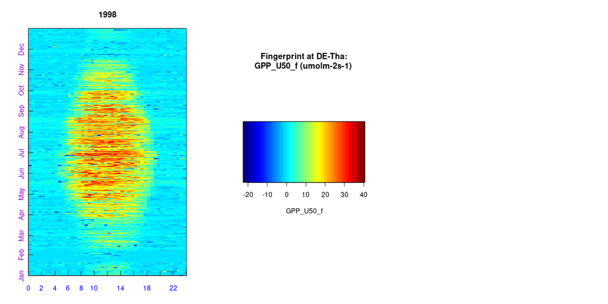

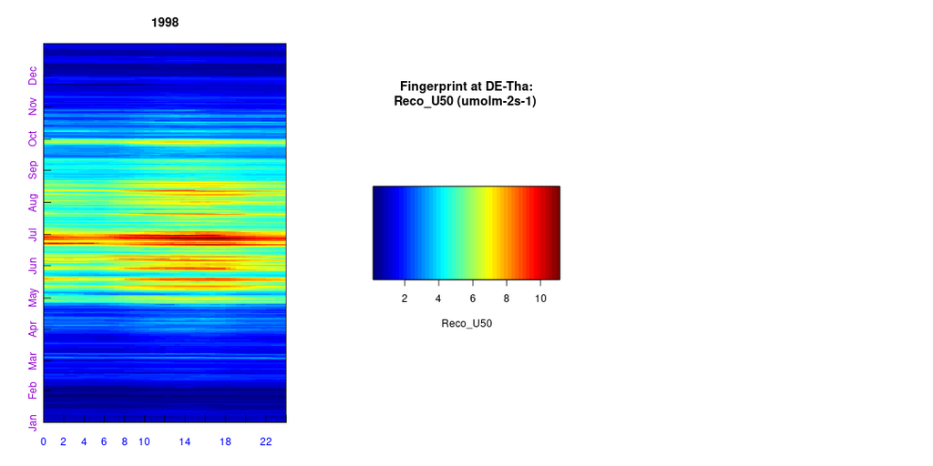

## Daytime partitioning

Repeated for each of the \(u_*\) threshold scenario (percentiles of \(u_{*Th}\) distribution)

```r
invisible(EProc$sGLFluxPartitionUStarScens())
grep("GPP.*_DT|Reco.*_DT",names(EProc$sExportResults()), value = TRUE)
```

```
##  [1] "Reco_DT_U05"      "GPP_DT_U05"       "Reco_DT_U05_SD"   "GPP_DT_U05_SD"
##  [5] "Reco_DT_U50"      "GPP_DT_U50"       "Reco_DT_U50_SD"   "GPP_DT_U50_SD"
##  [9] "Reco_DT_U95"      "GPP_DT_U95"       "Reco_DT_U95_SD"   "GPP_DT_U95_SD"
## [13] "Reco_DT_uStar"    "GPP_DT_uStar"     "Reco_DT_uStar_SD" "GPP_DT_uStar_SD"
```

It produces output columns `Reco_DT_<uStar>` and `GPP_DT_<uStar>` modified by the respective \(u_*\) threshold suffix in the REddyProc class.

`_SD` denotes the standard deviation of the prediction error.

## Fingerprint plots of Daytime \(R_{eco}\) and \(GPP\)

```r
EProc$sPlotFingerprint('GPP_DT_U50', Dir = "plots", Format = "png")
EProc$sPlotFingerprint('Reco_DT_U50', Dir = "plots", Format = "png")
```

\(GPP\)

\(R_{eco}\)

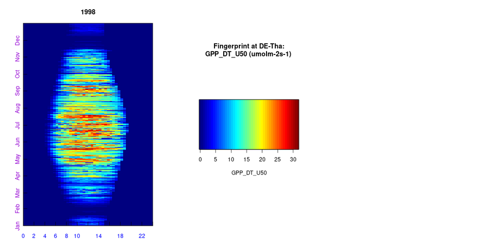

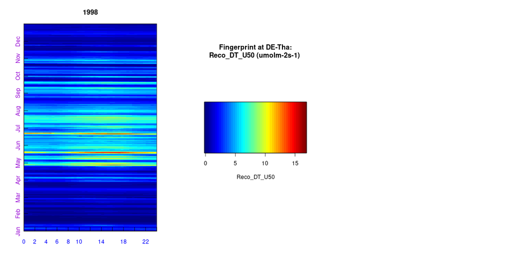

## Save the results

So far the results are stored internally in the REddyProc class. Get them as a data.frame:

```r
results = EProc$sExportResults()
# bind to original original data
appResults = cbind(EProc$sExportData(), results)
# save to tab-separated file
fWriteDataframeToFile(appResults, "DETha98_proc.txt")
```

```
## Number of NA convertered to '-9999': 607849
```

```
## Wrote tab separated textfile: DETha98_proc.txt
```